# Module 12 Final Code Deliverable

## Analysis Notebook

`notebooks/5.0_model_evaluation_and_interpretation.ipynb`

**Purpose:** Final model evaluation, diagnostics, and interpretation outputs.

## Reviewer Guide

This notebook compares model performance, interprets the final model, and generates the primary diagnostic outputs used in the report.

# Model Evaluation and Interpretation

**MEPS Capstone - Midterm Status** Group 6 | *Sriram Kannepalli* | ALY6980

## Scope

This project builds interpretable ML models on MEPS longitudinal data for adult, non-cancer populations to predict future inpatient utilization risk and support decision-making for multiple healthcare stakeholders.

## Data

Panels 23-27 longitudinal MEPS Household Component files (2018-2023), adult cohort (AGE >= 18), non-cancer only. This notebook uses the analysis-ready file produced in `1.0_data_integrity_and_cohort_definition.ipynb` and the model-ready file produced in `3.0_feature_preparation.ipynb`.

## Preprocessing

Key steps: parse fixed-width ASCII files, create AGE_MAX, filter adults, exclude cancer, treat negative survey codes as missing, encode categorical variables, and exclude Year-2 utilization/cost variables from predictors to avoid leakage.

## Methodology (this week)

Baseline and additional models are trained to predict `Y_IPDISY2_CLASS` (0, 1, 2+ inpatient discharges in Year 2). Evaluation emphasizes class-imbalance aware metrics (macro-F1, balanced accuracy, class-specific recall, PR-AUC for the high-risk class) plus confusion matrices and calibration.

**1. Imports and Configuration** Purpose: load libraries, set a random seed, and configure plotting.

```python
# Purpose: This notebook compares model performance, interprets the final model, and generates the primary diagnostic outputs used in the report. | code block 1.
import numpy as np
import pandas as pd
import matplotlib.pyplot as plt

from sklearn.model_selection import train_test_split
from sklearn.metrics import (
    accuracy_score,
    balanced_accuracy_score,
    f1_score,
    classification_report,
    confusion_matrix,
    ConfusionMatrixDisplay,
    precision_recall_curve,
    auc,
)
from sklearn.calibration import calibration_curve
from sklearn.ensemble import GradientBoostingClassifier, HistGradientBoostingClassifier, RandomForestClassifier
from sklearn.impute import SimpleImputer
from sklearn.utils.class_weight import compute_sample_weight

RANDOM_STATE = 42
plt.rcParams["figure.figsize"] = (6, 4)

print("Imports loaded. Random seed:", RANDOM_STATE)
```

```
Imports loaded. Random seed: 42
```

**2. Load Model-Ready Data** Purpose: load the preprocessed modeling dataset and inspect the target distribution.

```python
# Purpose: This notebook compares model performance, interprets the final model, and generates the primary diagnostic outputs used in the report. | code block 2.
DATA_PATH = "../data/processed/meps_group6_model_ready_events.parquet"
df = pd.read_parquet(DATA_PATH)

print("Loaded:", DATA_PATH)
print("Shape:", df.shape)

df.head()
df["Y_IPDISY2_CLASS"].value_counts(dropna=False).rename("count")
df["Y_IPDISY2_CLASS"].value_counts(normalize=True, dropna=False).round(3).rename("share")
```

```
Loaded: ../data/processed/meps_group6_model_ready_events.parquet
Shape: (30659, 132)
```

```
Y_IPDISY2_CLASS
0    0.926
1    0.059
2    0.015
Name: share, dtype: float64
```

```python
# Purpose: This notebook compares model performance, interprets the final model, and generates the primary diagnostic outputs used in the report. | code block 3.
# Drop high-missing predictors (>50%)
predictor_cols = [c for c in df.columns if c != "Y_IPDISY2_CLASS"]
missing_rate = df[predictor_cols].isna().mean()
high_missing = missing_rate[missing_rate > 0.5].index.tolist()
print("Dropping high-missing predictors:", high_missing)
df = df.drop(columns=high_missing)
```

```
Dropping high-missing predictors: ['DIABAGY1', 'ARTHAGY1', 'ASTHAGY1']
```

### Interpretation: Target Distribution

- The outcome is highly imbalanced: most people have 0 admissions and very few have 2+.
- This makes accuracy less informative, so we focus on macro-F1, balanced accuracy, and class-2 recall/PR-AUC.

**3. Train/Test Split** Purpose: define features and target, then create a stratified split for fair model comparison.

```python
# Purpose: This notebook compares model performance, interprets the final model, and generates the primary diagnostic outputs used in the report. | code block 4.
X = df.drop(columns=["Y_IPDISY2_CLASS"])
y = df["Y_IPDISY2_CLASS"].astype(int)

X_train, X_test, y_train, y_test = train_test_split(
    X,
    y,
    test_size=0.2,
    stratify=y,
    random_state=RANDOM_STATE,
)

print("Train shape:", X_train.shape, "Test shape:", X_test.shape)
print("Train class distribution:")
print(y_train.value_counts(normalize=True).round(3))
print("Test class distribution:")
print(y_test.value_counts(normalize=True).round(3))

# Impute missing values for models that do not handle NaN
imputer = SimpleImputer(strategy="median")
X_train_imp = pd.DataFrame(imputer.fit_transform(X_train), columns=X_train.columns, index=X_train.index)
X_test_imp = pd.DataFrame(imputer.transform(X_test), columns=X_test.columns, index=X_test.index)
```

```
Train shape: (24527, 128) Test shape: (6132, 128)
Train class distribution:
Y_IPDISY2_CLASS
0    0.926
1    0.059
2    0.015
Name: proportion, dtype: float64
Test class distribution:
Y_IPDISY2_CLASS
0    0.926
1    0.059
2    0.015
Name: proportion, dtype: float64
```

### Interpretation: Train/Test Split and Preparation

- The split is stratified, so class proportions are preserved in train and test.
- Missing values are imputed with the median for all models. Tree-based models are robust without scaling.

**4. Class Imbalance Weights** Purpose: compute sample weights to reduce bias toward the majority class.

```python
# Purpose: This notebook compares model performance, interprets the final model, and generates the primary diagnostic outputs used in the report. | code block 5.
sample_weight = compute_sample_weight(class_weight="balanced", y=y_train)
pd.Series(sample_weight).describe()
```

```
count    24527.000000
mean         1.000000
std          2.894839
min          0.360098
25%          0.360098
50%          0.360098
75%          0.360098
max         22.156278
dtype: float64
```

### Interpretation: Class Weights

- Rare classes receive higher weights so the model pays more attention to them during training.

**5. Train Baseline and Additional Models** Purpose: train baseline models and add new model types for this week's progress update.

```python
# Purpose: This notebook compares model performance, interprets the final model, and generates the primary diagnostic outputs used in the report. | code block 6.
models = {
    "Gradient Boosting": GradientBoostingClassifier(random_state=RANDOM_STATE),
    "HistGradientBoosting": HistGradientBoostingClassifier(
        random_state=RANDOM_STATE,
        max_depth=6,
    ),
    "Random Forest": RandomForestClassifier(
        n_estimators=300,
        random_state=RANDOM_STATE,
        class_weight="balanced",
        n_jobs=-1,
    ),
}

trained = {}
for name, model in models.items():
    if name in ["Gradient Boosting", "HistGradientBoosting"]:
        model.fit(X_train_imp, y_train, sample_weight=sample_weight)
    else:
        model.fit(X_train_imp, y_train)
    trained[name] = model

print("Trained models:", list(trained.keys()))
```

```
Trained models: ['Gradient Boosting', 'HistGradientBoosting', 'Random Forest']
```

**6. Model Evaluation Table** Purpose: evaluate models with imbalance-aware metrics and summarize in a comparison table.

```python
# Purpose: This notebook compares model performance, interprets the final model, and generates the primary diagnostic outputs used in the report. | code block 7.
results = []
preds = {}
probas = {}

y_test_bin = (y_test == 2).astype(int)

for name, model in trained.items():
    y_pred = model.predict(X_test_imp)
    y_proba = model.predict_proba(X_test_imp)

    preds[name] = y_pred
    probas[name] = y_proba

    report = classification_report(y_test, y_pred, output_dict=True, zero_division=0)

    class_index = list(model.classes_).index(2)
    precision, recall, _ = precision_recall_curve(y_test_bin, y_proba[:, class_index])
    pr_auc = auc(recall, precision)

    results.append({
        "Model": name,
        "Accuracy": accuracy_score(y_test, y_pred),
        "Balanced_Accuracy": balanced_accuracy_score(y_test, y_pred),
        "Macro_F1": f1_score(y_test, y_pred, average="macro"),
        "Recall_0": report["0"]["recall"],
        "Recall_1": report["1"]["recall"],
        "Recall_2": report["2"]["recall"],
        "PR_AUC_Class2": pr_auc,
    })

comparison = pd.DataFrame(results).sort_values("Macro_F1", ascending=False)
comparison
```

|  | Model | Accuracy | Balanced_Accuracy | Macro_F1 | Recall_0 | Recall_1 | Recall_2 | PR_AUC_Class2 |
| --- | --- | --- | --- | --- | --- | --- | --- | --- |
| 1 | HistGradientBoosting | 0.684932 | 0.507364 | 0.365444 | 0.708069 | 0.390110 | 0.423913 | 0.073870 |
| 0 | Gradient Boosting | 0.664057 | 0.523084 | 0.360713 | 0.684637 | 0.384615 | 0.500000 | 0.085869 |
| 2 | Random Forest | 0.923842 | 0.332687 | 0.320138 | 0.998062 | 0.000000 | 0.000000 | 0.087613 |

### Interpretation: Model Comparison

- HistGradientBoosting has the strongest overall balance (highest macro-F1).
- Gradient Boosting achieves the highest recall for class 2 (2+ admissions), which is useful for high-risk targeting.
- Random Forest shows high accuracy but poor balanced accuracy and weak minority recall, indicating majority-class bias.

**7. Confusion Matrices** Purpose: visualize error patterns for the baseline model and the model with the highest recall for class 2.

```
Best by Recall_2: Gradient Boosting
```

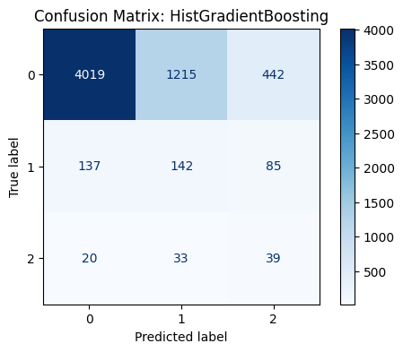

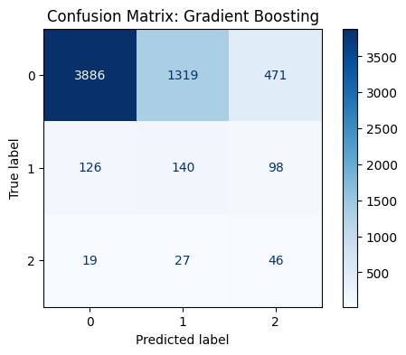

```python
# Purpose: This notebook compares model performance, interprets the final model, and generates the primary diagnostic outputs used in the report. | code block 8.
baseline_name = "HistGradientBoosting"
best_recall2_name = comparison.sort_values("Recall_2", ascending=False).iloc[0]["Model"]

names = [baseline_name]
if best_recall2_name != baseline_name:
    names.append(best_recall2_name)

print("Best by Recall_2:", best_recall2_name)

for name in names:
    cm = confusion_matrix(y_test, preds[name], labels=[0, 1, 2])
    disp = ConfusionMatrixDisplay(confusion_matrix=cm, display_labels=[0, 1, 2])
    disp.plot(cmap="Blues", values_format="d")
    plt.title(f"Confusion Matrix: {name}")
    plt.show()
```

### Interpretation: Confusion Matrix

- Most errors are between adjacent classes (0 vs 1 or 1 vs 2), not extreme jumps.
- The model captures some high-risk cases but also misses many and flags some non high-risk individuals.

**8. High-Risk Precision-Recall Curves** Purpose: examine precision-recall tradeoffs for predicting the high-risk class (2+ admissions).

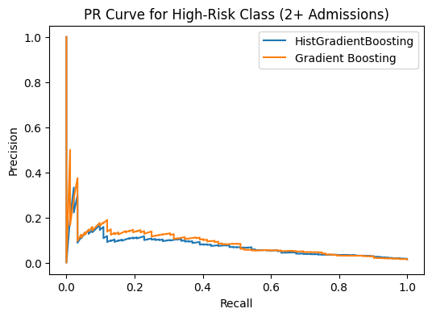

```python
# Purpose: This notebook compares model performance, interprets the final model, and generates the primary diagnostic outputs used in the report. | code block 9.
plt.figure(figsize=(6, 4))

names = [baseline_name]
if best_recall2_name != baseline_name:
    names.append(best_recall2_name)

for name in names:
    model = trained[name]
    class_index = list(model.classes_).index(2)
    precision, recall, _ = precision_recall_curve(y_test_bin, probas[name][:, class_index])
    plt.plot(recall, precision, label=name)

plt.xlabel("Recall")
plt.ylabel("Precision")
plt.title("PR Curve for High-Risk Class (2+ Admissions)")
plt.legend()
plt.show()
```

### Interpretation: PR Curve

- Precision falls as recall increases because class 2 is rare.
- Use the model as a ranking tool and choose a threshold based on acceptable false positives.

**9. Calibration Check** Purpose: assess probability calibration for the high-risk class.

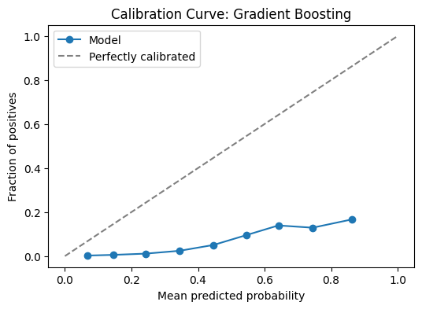

```python
# Purpose: This notebook compares model performance, interprets the final model, and generates the primary diagnostic outputs used in the report. | code block 10.
model = trained[best_recall2_name]
class_index = list(model.classes_).index(2)
prob_pos = probas[best_recall2_name][:, class_index]

frac_pos, mean_pred = calibration_curve(y_test_bin, prob_pos, n_bins=10)

plt.figure(figsize=(6, 4))
plt.plot(mean_pred, frac_pos, marker="o", label="Model")
plt.plot([0, 1], [0, 1], linestyle="--", color="gray", label="Perfectly calibrated")
plt.xlabel("Mean predicted probability")
plt.ylabel("Fraction of positives")
plt.title(f"Calibration Curve: {best_recall2_name}")
plt.legend()
plt.show()
```

### Interpretation: Calibration

- The curve below the diagonal indicates overestimation of risk probabilities.
- Treat probabilities as relative risk scores unless calibration is applied.

## Interpretation of Model Results

### Study Objective

The goal is to evaluate whether models trained on MEPS longitudinal survey data behave in a logical and interpretable way for predicting future inpatient utilization risk among non-cancer adults. The emphasis is risk stratification rather than chasing marginal accuracy gains.

### Outcome Distribution Context

The target is highly imbalanced: 92.6% have no inpatient admissions in Year 2, 5.9% have one, and 1.5% have two or more. This motivates metrics beyond overall accuracy, especially macro-F1, balanced accuracy, and class 2 recall/PR-AUC.

### Overall Model Performance

HistGradientBoosting achieved the strongest macro-F1 in this run, with Gradient Boosting close behind. Gradient Boosting delivered the highest recall for class 2 (2+ admissions), which is valuable for high-risk targeting. Random Forest produced high overall accuracy but much lower balanced accuracy and weaker recall for minority classes, suggesting majority-class bias.

### Risk Stratification Trade-offs

If the priority is balanced performance across all classes, HistGradientBoosting is the strongest choice. If the priority is capturing more 2+ admissions, Gradient Boosting is preferable.

### Probability Quality

PR-AUC values are low (~0.074?0.086), which is expected given the rarity of class 2 events. The calibration curve suggests overconfident probabilities for the high-risk class, so predicted probabilities should be interpreted as ranking scores rather than exact risk unless additional calibration is applied.

### Training Stability

For this weekly checkpoint, results should be treated as preliminary and interpreted as comparative signals rather than definitive performance.

### Next Steps

- Refine decision thresholds for class 2 targeting and consider probability calibration.
- Integrate insights into the Streamlit dashboard for stakeholder review.

```python
# Purpose: This notebook compares model performance, interprets the final model, and generates the primary diagnostic outputs used in the report. | code block 11.
```

## High-Cost Risk (Exploratory Extension)

**Goal:** Predict high-cost risk in Year 2 using Year 1 predictors only. **Definition:** High-cost = top 10% of `TOTEXPY2` (Year 2 total expenditures).

**A. Load Data and Define Target** Purpose: create a binary high-cost label from `TOTEXPY2`.

```python
# Purpose: This notebook compares model performance, interprets the final model, and generates the primary diagnostic outputs used in the report. | code block 12.
# Load analysis-ready data (contains Year 2 totals)
DATA_PATH_HC = "../data/processed/meps_group6_analysis_ready_events.parquet"
df_hc = pd.read_parquet(DATA_PATH_HC)

# Treat negative survey codes as missing
NEG_CODES = [-1, -7, -8, -9]
df_hc = df_hc.replace(NEG_CODES, np.nan)

# Define high-cost target from Year 2 total expenditures
TARGET_COST = "TOTEXPY2"

# Drop rows with missing target
hc = df_hc.dropna(subset=[TARGET_COST]).copy()

# Top 10% threshold
threshold = hc[TARGET_COST].quantile(0.90)
hc["Y_HIGH_COST"] = (hc[TARGET_COST] >= threshold).astype(int)

print("High-cost threshold (top 10%):", round(threshold, 2))
hc["Y_HIGH_COST"].value_counts(normalize=True).round(3)
```

```
High-cost threshold (top 10%): 18364.0
```

```
Y_HIGH_COST
0    0.9
1    0.1
Name: proportion, dtype: float64
```

### Interpretation: High-Cost Target

- The label represents the top 10% of Year 2 spending.
- This is a common and actionable threshold for payer/provider risk stratification.

**B. Feature Selection and Split** Purpose: build a Year 1 predictor set and avoid Year 2 leakage.

```python
# Purpose: This notebook compares model performance, interprets the final model, and generates the primary diagnostic outputs used in the report. | code block 13.
# Use Year 1 predictors and baseline characteristics only
ALLOWED_PREFIXES_HC = (
    'AGE', 'SEX', 'RACE', 'HISP',
    'EDUC', 'POVCAT', 'INSUR',
    'ASTH', 'DIAB', 'ARTH', 'HYPER', 'CHRON',
    'RTHLTH', 'MNHLTH',
    'TOTEXPY1', 'RXEXPY1', 'IPDISY1'
)

candidate_hc = [
    c for c in hc.columns
    if any(c.startswith(p) for p in ALLOWED_PREFIXES_HC) or c.endswith('_y1')
]

# Remove any Year 2 predictors to prevent leakage
candidate_hc = [c for c in candidate_hc if 'Y2' not in c]

# Explicit exclusions
EXCLUDE_HC = {'DUPERSID','PANEL','SOURCE_PANEL','CANCERY1','CANCERY2','TOTEXPY2','RXEXPY2','IPDISY2'}
candidate_hc = [c for c in candidate_hc if c not in EXCLUDE_HC]

# Add AGE_MAX if available
if 'AGE_MAX' in hc.columns and 'AGE_MAX' not in candidate_hc:
    candidate_hc.append('AGE_MAX')

X_hc = hc[candidate_hc].copy()
y_hc = hc['Y_HIGH_COST'].astype(int)

# Drop high-missing features (>50%)
missing_rate_hc = X_hc.isna().mean()
high_missing_hc = missing_rate_hc[missing_rate_hc > 0.5].index.tolist()
print('Dropping high-missing HC predictors:', high_missing_hc)
X_hc = X_hc.drop(columns=high_missing_hc)

print('Predictors:', len(X_hc.columns))
print('Target prevalence:')
print(y_hc.value_counts(normalize=True).round(3))
```

```
Dropping high-missing HC predictors: ['DIABAGY1', 'ARTHTPY1', 'ARTHAGY1', 'ASTHAGY1', 'ASTHEP1', 'ASTHEP3', 'ASTHEP5']
Predictors: 46
Target prevalence:
Y_HIGH_COST
0    0.9
1    0.1
Name: proportion, dtype: float64
```

```python
# Purpose: This notebook compares model performance, interprets the final model, and generates the primary diagnostic outputs used in the report. | code block 14.
# Train/test split for high-cost model
from sklearn.model_selection import train_test_split

X_train_hc, X_test_hc, y_train_hc, y_test_hc = train_test_split(
    X_hc,
    y_hc,
    test_size=0.2,
    stratify=y_hc,
    random_state=RANDOM_STATE,
)

# Impute missing values
imputer_hc = SimpleImputer(strategy="median")
X_train_hc_imp = pd.DataFrame(imputer_hc.fit_transform(X_train_hc), columns=X_train_hc.columns, index=X_train_hc.index)
X_test_hc_imp = pd.DataFrame(imputer_hc.transform(X_test_hc), columns=X_test_hc.columns, index=X_test_hc.index)

print("Train shape:", X_train_hc_imp.shape, "Test shape:", X_test_hc_imp.shape)
print("Train prevalence:")
print(y_train_hc.value_counts(normalize=True).round(3))
print("Test prevalence:")
print(y_test_hc.value_counts(normalize=True).round(3))
```

```
Train shape: (24527, 46) Test shape: (6132, 46)
Train prevalence:
Y_HIGH_COST
0    0.9
1    0.1
Name: proportion, dtype: float64
Test prevalence:
Y_HIGH_COST
0    0.9
1    0.1
Name: proportion, dtype: float64
```

**C. Train and Evaluate (High-Cost Risk)** Purpose: compare two tree-based models for high-cost risk prediction.

```python
# Purpose: This notebook compares model performance, interprets the final model, and generates the primary diagnostic outputs used in the report. | code block 15.
from sklearn.metrics import roc_auc_score, average_precision_score

sample_weight_hc = compute_sample_weight(class_weight="balanced", y=y_train_hc)

models_hc = {
    "Gradient Boosting": GradientBoostingClassifier(random_state=RANDOM_STATE),
    "HistGradientBoosting": HistGradientBoostingClassifier(
        random_state=RANDOM_STATE,
        max_depth=6,
    ),
}

trained_hc = {}
for name, model in models_hc.items():
    model.fit(X_train_hc_imp, y_train_hc, sample_weight=sample_weight_hc)
    trained_hc[name] = model

results_hc = []
for name, model in trained_hc.items():
    y_pred = model.predict(X_test_hc_imp)
    y_proba = model.predict_proba(X_test_hc_imp)[:, 1]

    results_hc.append({
        "Model": name,
        "Accuracy": accuracy_score(y_test_hc, y_pred),
        "Balanced_Accuracy": balanced_accuracy_score(y_test_hc, y_pred),
        "F1": f1_score(y_test_hc, y_pred),
        "Recall": classification_report(y_test_hc, y_pred, output_dict=True)["1"]["recall"],
        "ROC_AUC": roc_auc_score(y_test_hc, y_proba),
        "PR_AUC": average_precision_score(y_test_hc, y_proba),
    })

comparison_hc = pd.DataFrame(results_hc).sort_values("PR_AUC", ascending=False)
comparison_hc
```

|  | Model | Accuracy | Balanced_Accuracy | F1 | Recall | ROC_AUC | PR_AUC |
| --- | --- | --- | --- | --- | --- | --- | --- |
| 0 | Gradient Boosting | 0.805936 | 0.766754 | 0.425121 | 0.717781 | 0.840851 | 0.477123 |
| 1 | HistGradientBoosting | 0.819472 | 0.759773 | 0.431433 | 0.685155 | 0.841148 | 0.474108 |

### Interpretation: High-Cost Results

- High-cost is defined as the top 10% of Year-2 spending, which is a common and actionable threshold.
- ROC-AUC and PR-AUC show how well the model ranks high-cost risk above the 10% baseline.
- Gradient Boosting slightly leads in PR-AUC and recall, while HistGradientBoosting is more conservative.

**D. Confusion Matrix (Best PR-AUC)** Purpose: visualize errors for the best high-cost model.

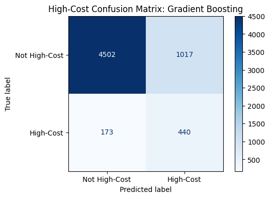

```python
# Purpose: This notebook compares model performance, interprets the final model, and generates the primary diagnostic outputs used in the report. | code block 16.
best_hc = comparison_hc.iloc[0]["Model"]

y_pred_best = trained_hc[best_hc].predict(X_test_hc_imp)

cm_hc = confusion_matrix(y_test_hc, y_pred_best, labels=[0, 1])
ConfusionMatrixDisplay(confusion_matrix=cm_hc, display_labels=["Not High-Cost", "High-Cost"]).plot(cmap="Blues", values_format="d")
plt.title(f"High-Cost Confusion Matrix: {best_hc}")
plt.show()
```

```python
# Purpose: This notebook compares model performance, interprets the final model, and generates the primary diagnostic outputs used in the report. | code block 17.
```

## Report Tables (for Word submission)

Purpose: Generate clean tables for the midterm report (Table 1-5).

```python
# Purpose: Table 1 - Inpatient target distribution
# Uses model-ready data (includes Y_IPDISY2_CLASS)
import pandas as pd
import numpy as np

df_report = pd.read_parquet(DATA_PATH)

table1 = (df_report["Y_IPDISY2_CLASS"]
          .value_counts(dropna=False)
          .rename_axis("Inpatient Admissions (Y2)")
          .to_frame("Count"))

table1["Share"] = (table1["Count"] / table1["Count"].sum()).round(3)

table1
```

| Inpatient Admissions (Y2) | Count | Share |
| --- | --- | --- |
| 0 | 28380 | 0.926 |
| 1 | 1818 | 0.059 |
| 2 | 461 | 0.015 |

```python
# Purpose: Table 3 - Missingness summary (top 20 predictors)
predictor_cols = [c for c in df_report.columns if c != "Y_IPDISY2_CLASS"]
missing_rate = df_report[predictor_cols].isna().mean().sort_values(ascending=False)

table3 = missing_rate.head(20).to_frame("Missing Share")

table3
```

|  | Missing Share |
| --- | --- |
| DIABAGY1 | 0.881144 |
| ASTHAGY1 | 0.870315 |
| ARTHAGY1 | 0.776477 |
| EDUCYR | 0.007339 |
| TOTEXPY1 | 0.001924 |
| RXEXPY1 | 0.001924 |
| AGE_MAX | 0.000000 |
| rx_count_y1 | 0.000000 |
| rx_cost_y1 | 0.000000 |
| ip_cost_y1 | 0.000000 |
| er_count_y1 | 0.000000 |
| er_cost_y1 | 0.000000 |
| cond_count_y1 | 0.000000 |
| chronic_cond_count_y1 | 0.000000 |
| icd10_unique_y1 | 0.000000 |
| SEX_1.0 | 0.000000 |
| SEX_2.0 | 0.000000 |
| SEX_nan | 0.000000 |
| RACEV1X_1.0 | 0.000000 |
| RACEV1X_2.0 | 0.000000 |

```python
# Purpose: Table 2 - High-cost target distribution (top 10%)
DATA_PATH_HC = "../data/processed/meps_group6_analysis_ready_events.parquet"
df_hc = pd.read_parquet(DATA_PATH_HC)

NEG_CODES = [-1, -7, -8, -9]
df_hc = df_hc.replace(NEG_CODES, np.nan)

TARGET_COST = "TOTEXPY2"
hc = df_hc.dropna(subset=[TARGET_COST]).copy()

threshold = hc[TARGET_COST].quantile(0.90)
hc["Y_HIGH_COST"] = (hc[TARGET_COST] >= threshold).astype(int)

print("High-cost threshold (top 10%):", round(threshold, 2))

table2 = (hc["Y_HIGH_COST"]
          .value_counts()
          .rename_axis("High-Cost (Top 10%)")
          .to_frame("Count"))

table2["Share"] = (table2["Count"] / table2["Count"].sum()).round(3)

table2
```

```
High-cost threshold (top 10%): 18364.0
```

| High-Cost (Top 10%) | Count | Share |
| --- | --- | --- |
| 0 | 27593 | 0.9 |
| 1 | 3066 | 0.1 |

```python
# Purpose: Table 4 - Inpatient model comparison
if 'comparison' not in globals():
    raise RuntimeError("Run the inpatient model evaluation section first to create 'comparison'.")

table4 = comparison.copy().round(3)
table4
```

|  | Model | Accuracy | Balanced_Accuracy | Macro_F1 | Recall_0 | Recall_1 | Recall_2 | PR_AUC_Class2 |
| --- | --- | --- | --- | --- | --- | --- | --- | --- |
| 1 | HistGradientBoosting | 0.685 | 0.507 | 0.365 | 0.708 | 0.390 | 0.424 | 0.074 |
| 0 | Gradient Boosting | 0.664 | 0.523 | 0.361 | 0.685 | 0.385 | 0.500 | 0.086 |
| 2 | Random Forest | 0.924 | 0.333 | 0.320 | 0.998 | 0.000 | 0.000 | 0.088 |

```python
# Purpose: Table 5 - High-cost model comparison
if 'comparison_hc' not in globals():
    raise RuntimeError("Run the high-cost model evaluation section first to create 'comparison_hc'.")

table5 = comparison_hc.copy().round(3)
table5
```

|  | Model | Accuracy | Balanced_Accuracy | F1 | Recall | ROC_AUC | PR_AUC |
| --- | --- | --- | --- | --- | --- | --- | --- |
| 0 | Gradient Boosting | 0.806 | 0.767 | 0.425 | 0.718 | 0.841 | 0.477 |
| 1 | HistGradientBoosting | 0.819 | 0.760 | 0.431 | 0.685 | 0.841 | 0.474 |

```python
# Purpose: This notebook compares model performance, interprets the final model, and generates the primary diagnostic outputs used in the report. | code block 23.
from sklearn.inspection import permutation_importance
import pandas as pd

# Choose the best inpatient model
best_model = trained["HistGradientBoosting"]  # or Gradient Boosting if you prefer Recall‑2

result = permutation_importance(
    best_model, X_test_imp, y_test, n_repeats=10, random_state=42
)

imp = pd.DataFrame({
    "feature": X_test_imp.columns,
    "importance": result.importances_mean
}).sort_values("importance", ascending=False)

imp.head(15)
```

|  | feature | importance |
| --- | --- | --- |
| 0 | EDUCYR | 0.005985 |
| 6 | ip_cost_y1 | 0.002870 |
| 8 | er_cost_y1 | 0.002805 |
| 60 | DIABDXY1_M18_1.0 | 0.001533 |
| 16 | RACEV1X_2.0 | 0.001305 |
| 101 | IPDISY1_1.0 | 0.000815 |
| 100 | IPDISY1_0.0 | 0.000783 |
| 88 | POVCATY1_4.0 | 0.000718 |
| 15 | RACEV1X_1.0 | 0.000620 |
| 61 | DIABDXY1_M18_2.0 | 0.000603 |
| 36 | RACEBX_3.0 | 0.000489 |
| 9 | cond_count_y1 | 0.000457 |
| 10 | chronic_cond_count_y1 | 0.000424 |
| 7 | er_count_y1 | 0.000424 |
| 18 | RACEV1X_4.0 | 0.000408 |

```python
# Purpose: This notebook compares model performance, interprets the final model, and generates the primary diagnostic outputs used in the report. | code block 24.
```

## Analysis Notebook

`notebooks/6.0_next_week_modeling_catboost_panel_calibration.ipynb`

**Purpose:** CatBoost panel split, calibration review, and lift analysis.

## Reviewer Guide

This notebook focuses on CatBoost panel validation, calibration behavior, and lift analysis for the rare 2+ admissions class.

# 6.0 Modeling: CatBoost + Panel Split + Calibration + Lift

Purpose: Extend the analysis with a stronger generalization test (panel-based split), add CatBoost, and produce decision-ready metrics (calibration + lift/deciles).

## Project Context

**Scope**: Build interpretable ML models on MEPS longitudinal data (adult, non-cancer) to predict future inpatient risk and exploratory high-cost risk.

**Data**: MEPS Panels 23-27 (2018-2023) using longitudinal, condition, and event files (ER/IP/Rx) plus appendix link files for data integration. Outcomes use Year-2 measures; predictors use Year-1 only.

**Preprocessing**: Parse fixed-width .dat/.ssp files, standardize missing codes, merge on DUPERSID + PANEL, construct Year-1 utilization and condition features, drop all Year-2 predictors to prevent leakage, and create model-ready parquet outputs.

**Analysis**: Train and evaluate CatBoost with panel-based validation (train Panels 23-26, test Panel 27). Report Macro-F1, PR-AUC for class 2+, calibration curve, and top-decile lift.

```python
# Purpose: Imports and configuration
import numpy as np
import pandas as pd
from pathlib import Path

from sklearn.metrics import (
    classification_report,
    balanced_accuracy_score,
    f1_score,
    precision_recall_curve,
    auc,
    confusion_matrix,
    ConfusionMatrixDisplay,
)
from sklearn.calibration import calibration_curve
import matplotlib.pyplot as plt

RANDOM_STATE = 42
np.random.seed(RANDOM_STATE)
```

```python
# Purpose: Load analysis-ready data (raw categorical fields)
DATA_PATH = Path('..') / 'data' / 'processed' / 'meps_group6_analysis_ready_events.parquet'

df = pd.read_parquet(DATA_PATH)
print('Loaded:', DATA_PATH)
print('Shape:', df.shape)
print('Panels:', sorted(df['PANEL'].unique()))

df.head(3)
```

```
Loaded: ..\data\processed\meps_group6_analysis_ready_events.parquet
Shape: (31138, 72)
Panels: [np.int64(23), np.int64(24), np.int64(25), np.int64(26), np.int64(27)]
```

|  | DUPERSID | PANEL | AGE1X | AGE2X | AGE3X | AGE4X | AGE5X | AGEY1X | AGEY2X | AGELSTY1 | ... | rx_count_y1 | rx_cost_y1 | ip_count_y1 | ip_cost_y1 | er_count_y1 | er_cost_y1 | cond_count_y1 | chronic_cond_count_y1 | injury_any_y1 | icd10_unique_y1 |
| --- | --- | --- | --- | --- | --- | --- | --- | --- | --- | --- | --- | --- | --- | --- | --- | --- | --- | --- | --- | --- | --- |
| 0 | 2320002101 | 23 | 30 | 30 | 31 | 32 | 32 | 31 | 32 | 31 | ... | 0.0 | 0.0 | 0.0 | 0.0 | 0.0 | 0.0 | 0.0 | 0.0 | 0.0 | 0.0 |
| 1 | 2320002102 | 23 | 41 | 41 | 41 | 42 | 42 | 41 | 42 | 41 | ... | 0.0 | 0.0 | 0.0 | 0.0 | 0.0 | 0.0 | 0.0 | 0.0 | 0.0 | 0.0 |
| 2 | 2320005101 | 23 | 70 | 71 | 71 | 72 | 72 | 71 | 72 | 71 | ... | 0.0 | 0.0 | 0.0 | 0.0 | 0.0 | 0.0 | 0.0 | 0.0 | 0.0 | 0.0 |

3 rows × 72 columns

```python
# Purpose: Create target (inpatient risk: 0/1/2+)
TARGET_RAW = 'IPDISY2'

# Treat negative survey codes as missing for the target
NEG_CODES = [-1, -7, -8, -9]
df[TARGET_RAW] = df[TARGET_RAW].replace(NEG_CODES, np.nan)

def make_ipdisy2_class(x):
    if pd.isna(x):
        return np.nan
    if x == 0:
        return 0
    if x == 1:
        return 1
    if x >= 2:
        return 2
    return np.nan

df['Y_IPDISY2_CLASS'] = df[TARGET_RAW].apply(make_ipdisy2_class)

print(df['Y_IPDISY2_CLASS'].value_counts(dropna=False))
```

```
Y_IPDISY2_CLASS
0.0    28380
1.0     1818
NaN      479
2.0      461
Name: count, dtype: int64
```

```python
# Purpose: Define Y1-only features and remove leakage
EXCLUDE_COLS = {
    'DUPERSID',
    'CANCERY1', 'CANCERY2',
    'IPDISY2',
    'Y_IPDISY2_CLASS',
}

# Drop any Year-2 predictors
leak_cols = [c for c in df.columns if 'Y2' in c]

# Candidate features: Y1 + engineered _y1 features
ALLOWED_PREFIXES = (
    'AGE', 'SEX', 'RACE', 'HISP',
    'EDUC', 'POVCAT', 'INSUR',
    'ASTH', 'DIAB', 'ARTH', 'HYPER', 'CHRON',
    'RTHLTH', 'MNHLTH',
    'ERDISY1', 'IPDISY1',
    'TOTEXPY1', 'RXEXPY1'
)

candidate_features = [
    c for c in df.columns
    if any(c.startswith(p) for p in ALLOWED_PREFIXES) or c.endswith('_y1')
]

# Add AGE_MAX if present
if 'AGE_MAX' in df.columns and 'AGE_MAX' not in candidate_features:
    candidate_features.append('AGE_MAX')

# Apply exclusions
candidate_features = [c for c in candidate_features if c not in EXCLUDE_COLS]
candidate_features = [c for c in candidate_features if c not in leak_cols]

print('Feature count before missingness filter:', len(candidate_features))
```

```
Feature count before missingness filter: 53
```

```python
# Purpose: Remove high-missing features (>50%) and redundant AGE columns
X = df[candidate_features].copy()

missing_rate = X.isna().mean()
high_missing = missing_rate[missing_rate > 0.5].index.tolist()
print('Dropping high-missing:', high_missing)
X = X.drop(columns=high_missing)

# Reduce AGE redundancy: keep only AGE_MAX if present
if 'AGE_MAX' in X.columns:
    age_cols_to_drop = [c for c in X.columns if c.startswith('AGE') and c != 'AGE_MAX']
    X = X.drop(columns=age_cols_to_drop)

print('Final feature count:', X.shape[1])
```

```
Dropping high-missing: ['ASTHEP5']
Final feature count: 45
```

```python
# Purpose: Prepare target and panel-based split
# Keep rows with valid target
mask = df['Y_IPDISY2_CLASS'].notna()
X = X.loc[mask].copy()
y = df.loc[mask, 'Y_IPDISY2_CLASS'].astype(int)
panels = df.loc[mask, 'PANEL']

train_panels = [23, 24, 25, 26]
test_panels = [27]

train_idx = panels.isin(train_panels)
test_idx = panels.isin(test_panels)

X_train, y_train = X[train_idx], y[train_idx]
X_test, y_test = X[test_idx], y[test_idx]

print('Train rows:', X_train.shape[0], 'Test rows:', X_test.shape[0])
print('Train class distribution:', y_train.value_counts(normalize=True).round(3))
print('Test class distribution:', y_test.value_counts(normalize=True).round(3))
```

```
Train rows: 24919 Test rows: 5740
Train class distribution: Y_IPDISY2_CLASS
0    0.926
1    0.059
2    0.015
Name: proportion, dtype: float64
Test class distribution: Y_IPDISY2_CLASS
0    0.925
1    0.062
2    0.014
Name: proportion, dtype: float64
```

```python
# Purpose: Identify categorical columns for CatBoost
import pandas as pd

X_train = X_train.copy()
X_test = X_test.copy()

cat_cols = []
for c in X_train.columns:
    if X_train[c].dtype == 'object':
        cat_cols.append(c)
    elif pd.api.types.is_integer_dtype(X_train[c]) and X_train[c].nunique() <= 50:
        cat_cols.append(c)

# Cast categorical columns to string dtype to avoid pandas warnings
dtype_map = {c: 'string' for c in cat_cols}
X_train = X_train.astype(dtype_map)
X_test = X_test.astype(dtype_map)

X_train[cat_cols] = X_train[cat_cols].fillna('NA')
X_test[cat_cols] = X_test[cat_cols].fillna('NA')

cat_feature_indices = [X_train.columns.get_loc(c) for c in cat_cols]
print('Categorical features:', len(cat_cols))
```

```
Categorical features: 29
```

```python
# Purpose: Train CatBoost with class weights
# If catboost is not installed: pip install catboost
from catboost import CatBoostClassifier

# Compute inverse-frequency class weights
class_counts = y_train.value_counts().sort_index()
class_weights = (class_counts.sum() / class_counts).values.tolist()
print('Class weights:', class_weights)

cat_model = CatBoostClassifier(
    loss_function='MultiClass',
    eval_metric='TotalF1',
    iterations=300,
    depth=6,
    learning_rate=0.1,
    random_seed=RANDOM_STATE,
    verbose=False,
    class_weights=class_weights
)

cat_model.fit(X_train, y_train, cat_features=cat_feature_indices)
print('CatBoost trained.')
```

```
Class weights: [1.0800537447988905, 17.021174863387976, 65.0626631853786]
CatBoost trained.
```

```python
# Purpose: Evaluate CatBoost (Macro-F1, Balanced Accuracy, PR-AUC for class 2)
from sklearn.metrics import accuracy_score

y_pred = cat_model.predict(X_test)
y_pred = y_pred.flatten().astype(int)

y_proba = cat_model.predict_proba(X_test)

print('Accuracy:', round(accuracy_score(y_test, y_pred), 3))
print('Balanced Acc:', round(balanced_accuracy_score(y_test, y_pred), 3))
print('Macro-F1:', round(f1_score(y_test, y_pred, average='macro'), 3))

report = classification_report(y_test, y_pred, output_dict=True, zero_division=0)
print('Recall class 2:', round(report['2']['recall'], 3))

# PR-AUC for class 2 (2+ admissions)
y_test_bin = (y_test == 2).astype(int)
precision, recall, _ = precision_recall_curve(y_test_bin, y_proba[:, 2])
pr_auc = auc(recall, precision)
print('PR-AUC class 2:', round(pr_auc, 3))
```

```
Accuracy: 0.741
Balanced Acc: 0.559
Macro-F1: 0.416
Recall class 2: 0.41
PR-AUC class 2: 0.14
```

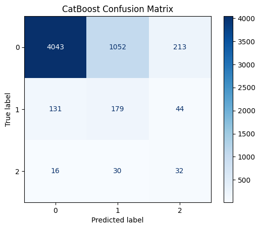

```python
# Purpose: Confusion matrix (CatBoost)
cm = confusion_matrix(y_test, y_pred, labels=[0, 1, 2])
ConfusionMatrixDisplay(confusion_matrix=cm, display_labels=[0, 1, 2]).plot(cmap='Blues', values_format='d')
plt.title('CatBoost Confusion Matrix')
plt.show()
```

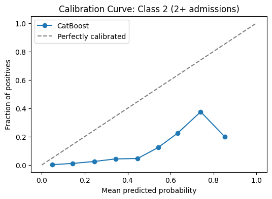

```python
# Purpose: Calibration curve for class 2
frac_pos, mean_pred = calibration_curve(y_test_bin, y_proba[:, 2], n_bins=10)

plt.figure(figsize=(6,4))
plt.plot(mean_pred, frac_pos, marker='o', label='CatBoost')
plt.plot([0,1],[0,1], linestyle='--', color='gray', label='Perfectly calibrated')
plt.xlabel('Mean predicted probability')
plt.ylabel('Fraction of positives')
plt.title('Calibration Curve: Class 2 (2+ admissions)')
plt.legend()
plt.show()
```

```python
# Purpose: Lift / decile analysis for class 2
# Rank by predicted probability for class 2
score_df = pd.DataFrame({
    'y_true': y_test_bin,
    'score': y_proba[:, 2]
})

score_df['decile'] = pd.qcut(score_df['score'], 10, labels=False, duplicates='drop')

lift_table = (score_df.groupby('decile')
              .agg(n=('y_true','size'),
                   positives=('y_true','sum'))
              .reset_index())

lift_table['rate'] = lift_table['positives'] / lift_table['n']
base_rate = score_df['y_true'].mean()
lift_table['lift'] = (lift_table['rate'] / base_rate)

lift_table = lift_table.sort_values('decile', ascending=False).reset_index(drop=True)

print('Base rate (class 2):', round(base_rate, 4))
print('Top decile rate:', round(lift_table.loc[0, 'rate'], 4))
print('Top decile lift:', round(lift_table.loc[0, 'lift'], 2))

lift_table
```

```
Base rate (class 2): 0.0136
Top decile rate: 0.0749
Top decile lift: 5.51
```

|  | decile | n | positives | rate | lift |
| --- | --- | --- | --- | --- | --- |
| 0 | 9 | 574 | 43 | 0.074913 | 5.512821 |
| 1 | 8 | 574 | 15 | 0.026132 | 1.923077 |
| 2 | 7 | 574 | 6 | 0.010453 | 0.769231 |
| 3 | 6 | 574 | 7 | 0.012195 | 0.897436 |
| 4 | 5 | 574 | 3 | 0.005226 | 0.384615 |
| 5 | 4 | 574 | 1 | 0.001742 | 0.128205 |
| 6 | 3 | 574 | 2 | 0.003484 | 0.256410 |
| 7 | 2 | 574 | 0 | 0.000000 | 0.000000 |
| 8 | 1 | 574 | 1 | 0.001742 | 0.128205 |
| 9 | 0 | 574 | 0 | 0.000000 | 0.000000 |

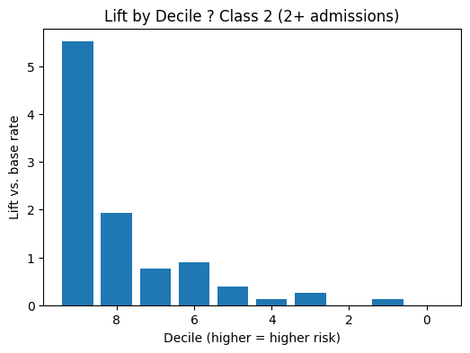

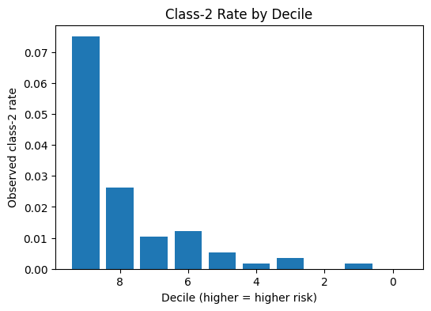

```python
# Purpose: Visualize lift by decile (Class 2)
plt.figure(figsize=(6,4))
plt.bar(lift_table['decile'].astype(int), lift_table['lift'])
plt.xlabel('Decile (higher = higher risk)')
plt.ylabel('Lift vs. base rate')
plt.title('Lift by Decile ? Class 2 (2+ admissions)')
plt.gca().invert_xaxis()
plt.show()

# Purpose: Visualize class-2 rate by decile
plt.figure(figsize=(6,4))
plt.bar(lift_table['decile'].astype(int), lift_table['rate'])
plt.xlabel('Decile (higher = higher risk)')
plt.ylabel('Observed class-2 rate')
plt.title('Class-2 Rate by Decile')
plt.gca().invert_xaxis()
plt.show()
```

## Interpretation Notes

- **Panel-based validation** (train 23-26, test 27) provides a stronger generalization check than random splits.
- **CatBoost** is well-suited for mixed numeric/categorical data and often performs well on imbalanced classes.
- **Calibration** helps interpret predicted probabilities for real-world decision thresholds.
- **Lift/decile analysis** shows how much better the top-risk group is compared to random selection.

## Interpretation (CatBoost Panel Split)

- **Generalization**: Using panel-based validation (train 23?26, test 27) provides a stricter, year-forward test than random splits.
- **Model balance**: Macro-F1 and balanced accuracy indicate the model is not dominated by the majority class.
- **High-risk recall**: Recall for class 2+ reflects how many high-risk patients are captured.
- **Ranking quality**: PR-AUC for class 2 should be compared to the base rate; values well above the base rate indicate useful ranking.
- **Lift**: Top-decile lift shows how much better the top 10% predicted group is compared to random selection.

## SMOTENC + CatBoost (Exploratory)

This section tests imbalance-aware resampling using SMOTENC (training only) with a CatBoost multiclass model.

```python
# Purpose: Import SMOTENC (imbalanced-learn)
try:
    from imblearn.over_sampling import SMOTENC
except ImportError as e:
    raise ImportError('Install imbalanced-learn: pip install imbalanced-learn') from e
```

```python
# Purpose: Prepare train/test matrices for SMOTENC (train only)
X_train_sm = X.loc[train_idx].copy()
X_test_sm = X.loc[test_idx].copy()
y_train_sm = y.loc[train_idx].copy()
y_test_sm = y.loc[test_idx].copy()

cost_count_cols = [c for c in X_train_sm.columns if c.endswith('_cost_y1') or c.endswith('_count_y1')]
numeric_force = set(cost_count_cols + ['AGE_MAX','TOTEXPY1','RXEXPY1','IPDISY1'])
cat_cols_sm = []
for c in X_train_sm.columns:
    if c in numeric_force:
        continue
    if X_train_sm[c].dtype == 'object':
        cat_cols_sm.append(c)
    elif pd.api.types.is_integer_dtype(X_train_sm[c]) and X_train_sm[c].nunique(dropna=True) <= 50:
        cat_cols_sm.append(c)
    elif pd.api.types.is_float_dtype(X_train_sm[c]):
        vals = X_train_sm[c].dropna()
        if len(vals) > 0 and (vals % 1 == 0).all() and vals.nunique() <= 50:
            cat_cols_sm.append(c)

num_cols_sm = [c for c in X_train_sm.columns if c not in cat_cols_sm]

from sklearn.impute import SimpleImputer
num_imputer = SimpleImputer(strategy='median')
X_train_sm[num_cols_sm] = num_imputer.fit_transform(X_train_sm[num_cols_sm])
X_test_sm[num_cols_sm] = num_imputer.transform(X_test_sm[num_cols_sm])

X_train_sm[cat_cols_sm] = X_train_sm[cat_cols_sm].fillna(-1).astype(int)
X_test_sm[cat_cols_sm] = X_test_sm[cat_cols_sm].fillna(-1).astype(int)

cat_idx_sm = [X_train_sm.columns.get_loc(c) for c in cat_cols_sm]
print('SMOTENC categorical features:', len(cat_cols_sm))
```

```
SMOTENC categorical features: 30
```

```python
# Purpose: Apply SMOTENC on training data only
smote = SMOTENC(categorical_features=cat_idx_sm, random_state=RANDOM_STATE)
X_train_res, y_train_res = smote.fit_resample(X_train_sm, y_train_sm)

print('Before SMOTE:')
print(y_train_sm.value_counts())
print('After SMOTE:')
print(pd.Series(y_train_res).value_counts())
```

```
Before SMOTE:
Y_IPDISY2_CLASS
0    23072
1     1464
2      383
Name: count, dtype: int64
After SMOTE:
Y_IPDISY2_CLASS
0    23072
1    23072
2    23072
Name: count, dtype: int64
```

```python
# Purpose: Train CatBoost on SMOTENC-resampled data
from catboost import CatBoostClassifier

class_counts = pd.Series(y_train_res).value_counts().sort_index()
class_weights_sm = (class_counts.sum() / class_counts).values.tolist()

cat_model_sm = CatBoostClassifier(
    loss_function='MultiClass',
    eval_metric='TotalF1',
    iterations=300,
    depth=6,
    learning_rate=0.1,
    random_seed=RANDOM_STATE,
    verbose=False,
    class_weights=class_weights_sm
)
cat_model_sm.fit(X_train_res, y_train_res, cat_features=cat_idx_sm)
print('CatBoost (SMOTENC) trained.')
```

```
CatBoost (SMOTENC) trained.
```

```python
# Purpose: Evaluate CatBoost (SMOTENC) on panel test set
from sklearn.metrics import accuracy_score, balanced_accuracy_score, f1_score, classification_report, precision_recall_curve, auc

y_pred_sm = cat_model_sm.predict(X_test_sm).flatten().astype(int)
y_proba_sm = cat_model_sm.predict_proba(X_test_sm)

print('Accuracy:', round(accuracy_score(y_test_sm, y_pred_sm), 3))
print('Balanced Acc:', round(balanced_accuracy_score(y_test_sm, y_pred_sm), 3))
print('Macro-F1:', round(f1_score(y_test_sm, y_pred_sm, average='macro'), 3))

report_sm = classification_report(y_test_sm, y_pred_sm, output_dict=True, zero_division=0)
print('Recall class 2:', round(report_sm['2']['recall'], 3))

y_test_bin_sm = (y_test_sm == 2).astype(int)
precision, recall, _ = precision_recall_curve(y_test_bin_sm, y_proba_sm[:, 2])
pr_auc_sm = auc(recall, precision)
print('PR-AUC class 2:', round(pr_auc_sm, 3))
```

```
Accuracy: 0.909
Balanced Acc: 0.374
Macro-F1: 0.384
Recall class 2: 0.077
PR-AUC class 2: 0.104
```

```python
# Purpose: Lift/decile analysis for class 2 (SMOTENC)
score_df_sm = pd.DataFrame({
    'y_true': y_test_bin_sm,
    'score': y_proba_sm[:, 2]
})
score_df_sm['decile'] = pd.qcut(score_df_sm['score'], 10, labels=False, duplicates='drop')
lift_sm = score_df_sm.groupby('decile').agg(n=('y_true','size'), positives=('y_true','sum'))
lift_sm['rate'] = lift_sm['positives'] / lift_sm['n']
base_rate = score_df_sm['y_true'].mean()
lift_sm['lift'] = (lift_sm['rate'] / base_rate).round(3)
lift_sm = lift_sm.sort_index(ascending=False)
print('Base rate:', round(base_rate, 4))
lift_sm
```

```
Base rate: 0.0136
```

| decile | n | positives | rate | lift |
| --- | --- | --- | --- | --- |
| 9 | 574 | 36 | 0.062718 | 4.615 |
| 8 | 574 | 12 | 0.020906 | 1.538 |
| 7 | 574 | 5 | 0.008711 | 0.641 |
| 6 | 574 | 9 | 0.015679 | 1.154 |
| 5 | 574 | 3 | 0.005226 | 0.385 |
| 4 | 574 | 3 | 0.005226 | 0.385 |
| 3 | 574 | 5 | 0.008711 | 0.641 |
| 2 | 574 | 1 | 0.001742 | 0.128 |
| 1 | 574 | 2 | 0.003484 | 0.256 |
| 0 | 574 | 2 | 0.003484 | 0.256 |